# Draft

### Datagoons

Koen Hommels (14649365)

Ricky Speijker (14668971)

Poeyan Soud Alizadeh (14110830)

Silas Postma (14668599)

# Urbanization: a threat or opportunity?

Urbanization is the process by which an increasing percentage of a population comes to live in urban areas. This transformative phenomenon is driven by various factors, including economic development, social changes, and technological advancements. As cities grow and evolve, they become hubs of innovation, culture, and opportunity, attracting people from rural areas in search of better employment, education, and lifestyle prospects. However, urbanization also brings challenges such as overcrowding, environmental degradation, and strain on infrastructure and public services. In this data story, we will explore two primary perspectives on urbanization: Urbanization is good for a country and urbanization is bad for a country.

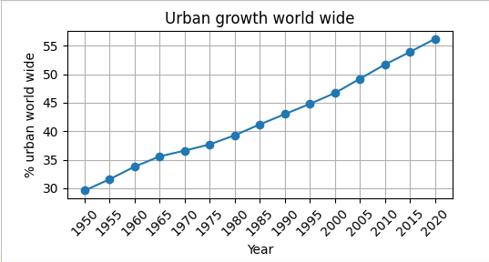

## Life expectancy

[interactive chart not shown]

We use the dataset on urbanization previously mentioned in this report. The variables used are the countries, excluding the first 16 entries in the dataset because those are continents or the world. Additionally, we use the urbanization percentage of each country in 2018. From the second dataset on life expectancy, we filtered the data to include only the year 2018 to ensure consistency with the other dataset. We then selected the variables for life expectancy and countries. We decided that a scatter plot would best visualize this relationship, so that is what we chose.

A scatter plot analysis of life expectancy versus the percentage of urban population in various countries reveals a positive correlation between the two variables. The plot, created using the two datasets in the year 2018, shows that as the percentage of a country's urban population increases, so does the life expectancy of its citizens.

Countries with high urbanization rates, such as Japan, Germany, and the United States, exhibit life expectancies that surpass 80 years. These countries benefit from advanced healthcare systems, widespread public health initiatives, and a higher standard of living, which are more prevalent in urban settings. But, countries with lower levels of urbanization often have shorter life expectancies, reflecting the challenges faced by rural areas, such as limited access to healthcare and lower economic development.

## Climate Change

[figure not shown]

## Economic Growth

### Preprocessing

To compare the income category and urban population of a nation, the following datasets were used:

- *'Percentage of Population at Mid-Year Residing in Urban Areas by region, subregion, and country, 1950-2050'* by the United Nations.
- *'Average Annual Rate of Change of the Urban Population by region, subregion, and country, 1950-2050 (percent)'* by the United Nations.
- *'GDP per capita'* from Our World in Data.

Steps taken during preprocessing:

- The datasets by the UN both had a title and description at the top, complicating their usage. Hence, both were removed.
- The data was in the European notation for decimals, meaning the commas were replaced with dots and converted back to integers.
- In the third dataset, all the data was put in rows instead of an easily usable table. The dataset was pivoted relative to the *'Entity'* row.

Finally, all datasets were merged into a single dataset to be analyzed. They were merged using *'Region, subregion, country or area'* for the UN datasets, and *'Entity'* for the *Our World in Data* dataset.

### Does urbanisation lead to wealth?

An idea that many people share of less developed countries is that the population of those countries mainly live on farms, in smaller villages, etc. More wealthy countries seem to invest more in their cities; building skyscrapers, investing in universities, and creating large suburbs. This idea would favor the pro-urbanisation side of this debate. To put this to the test, the percentage of the population living in urban areas is compared to the GDP category. GDP stands for 'gross domestic product', and is an accessible way to compare the wealth of nations and regions. For this graph the countries have been split up into quartiles.

[interactive chart not shown]

After visualizing the data, it becomes apparent that the countries with a higher GDP make up most of the countries with the largest proportion of the population living in urban areas (see the graph with *'GDP Category'* or *'Urban Population'* enabled). To support the idea that urbanization leads to a higher GDP, it has to be believed that the correlation between the two is *caused* by the rising urbanization. This is argued in Glaeser, E. L., & Gottlieb, J. D. (2009). *"The Wealth of Cities: Agglomeration Economies and Spatial Equilibrium in the United States". Journal of Economic Literature, 47(4), 983-1028*. This paper supports the notion that urbanization drives economic growth by fostering environments where innovation and productivity can flourish. It emphasizes that cities, through agglomeration economies, become centers of economic activity that significantly contribute to higher GDP.

However, there are many other articles that contradict this idea. One of those papers builds a strong case supporting the idea that it is not urbanization that leads to economic growth, but in fact the other way around. Bloom, D. E., Canning, D., & Fink (2008) argue in their paper *"Urbanization and the Wealth of Nations"* that economic growth precedes urbanization, as higher GDP and economic opportunities in urban areas attract rural populations.

### Air pollution

Typically, countries that have more urbanization have more cars and bigger industries. This naturally leads to more CO2 emissions, like we have seen in the ‘climate change’ section. This led us to ask the question how the countries are affected by these kinds of air pollution. The year of 2019 was investigated.

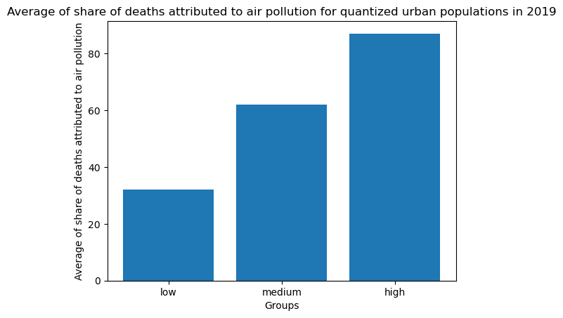

These results show that there is a trend. When split between three levels of urbanization, we can see that countries with the highest level of urbanization have the highest average of share of deaths attributed to air pollution, while the countries with the lowest level of urbanization have the lowest share of deaths. Interestingly, in the section ‘life expectancy’, we saw that countries with high levels of urbanization have better life expactancies.

Opponents of urbanization can point out that urbanization will lead to higher deaths. However, looking at this through the lens of quantiles will not tell the full story according to proponents of urbanization. If we look at the highest developed countries who have the highest levels of urbanization, we do not see a high level of share of deaths attributed to air pollution, which is visible in the next graph.

*This graph is still a concept*

[interactive chart not shown]